# Introduction to tableHTML

09 October 2018

## Contents

- Introduction to the authors
- Motivation: Why develop the package?
- What are HTML tables?
- What is tableHTML?
- Basic syntax & features of tableHTML
- add_css_*() family of functions
- tableHTML and shiny
- Conditional formatting
- Themes
- confution matrix

## Introduction to the authors

### Theo Boutaris

Theo is a Data Scientist currently residing in the UK. He has a passion for statistics and coding, which naturally led him to follow the Data Science path. He is an R evangelist and open source supporter and tries to give back to the community in his free time. He originates from the great city of Thessaloniki in Greece. When not coding, he plays football, listens to music or plays Dota2.

### Clemens Zauchner

Studied business informatics in Innsbruck and data science in London. Worked with companies like OMV, easyJet, and Sainsbury’s. Currently Data Scientist @ The Unbelievable Machine Company. Co-author of open source R package tableHTML, a tool to create and style HTML tables from R.

## Motivation: Why develop the package?

- Development started in 2016
- While developing a [football app](https://lyzander.shinyapps.io/FootballeR/) using shiny, it was somewhat difficult to build a pretty HTML table
- Example: drawing vertival lines every three columns seemd like a difficult task
- even using great packages like `xtable`

## What is tableHTML?

- A package for building CSS-ible HTML tables in an easy and intuitive way
- Compatible with any application that accepts HTML (e.g. shiny, rmarkdown, Outlook, PowerPoint, Word)
- The main function tableHTML converts a data.frame or matrix or any other object that can be converted into a data.frame into an HTML table
- Using the function on R Studio will print the table on the viewer otherwise it will use the default browser
- The default tables are built without any CSS in order to allow for full flexibility although two themes are included
- Re-exports the pipe `%>%` operator

## What are HTML tables?

```html
<table style="width:100%">
  <thead>
    <tr>
      <th>Firstname</th>
      <th>Lastname</th>
      <th>Age</th>
    </tr>
  </thead>
  <tbody>
    <tr>
      <td>Jill</td>
      <td>Smith</td>
      <td>50</td>
    </tr>
    <tr>
      <td>Eve</td>
      <td>Jackson</td>
      <td>94</td>
    </tr>
  </tbody>
</table>
```

## Basic syntax

```r
library(tableHTML)

mtcars %>%
  head(5) %>%
  tableHTML(widths = c(140, rep(50, 11)))
```

|  | mpg | cyl | disp | hp | drat | wt | qsec | vs | am | gear | carb |
| --- | --- | --- | --- | --- | --- | --- | --- | --- | --- | --- | --- |
| Mazda RX4 | 21 | 6 | 160 | 110 | 3.9 | 2.62 | 16.46 | 0 | 1 | 4 | 4 |
| Mazda RX4 Wag | 21 | 6 | 160 | 110 | 3.9 | 2.875 | 17.02 | 0 | 1 | 4 | 4 |
| Datsun 710 | 22.8 | 4 | 108 | 93 | 3.85 | 2.32 | 18.61 | 1 | 1 | 4 | 1 |
| Hornet 4 Drive | 21.4 | 6 | 258 | 110 | 3.08 | 3.215 | 19.44 | 1 | 0 | 3 | 1 |
| Hornet Sportabout | 18.7 | 8 | 360 | 175 | 3.15 | 3.44 | 17.02 | 0 | 0 | 3 | 2 |

## Features of tableHTML

- New headers
- Second headers
- Row names
- Row groups
- Add a caption / footer

```r
mtcars %>%
  head(14) %>%
  tableHTML(widths = c(120, 140, rep(45, 11)),
            second_headers = list(c(2, 2, 4, 5), c('', 'col1', 'col2', 'col3')),
            row_groups = list(c(7, 7), c('Group1', 'Group2')),
            caption = 'This is a caption',
            footer = 'This is a footer')
```

## Example

This is a caption

This is a footer

|  |  | col1 mpg | col1 cyl | col2 disp | col2 hp | col2 drat | col2 wt | col3 qsec | col3 vs | col3 am | col3 gear | col3 carb |
| --- | --- | --- | --- | --- | --- | --- | --- | --- | --- | --- | --- | --- |
| Group1 | Mazda RX4 | 21 | 6 | 160 | 110 | 3.9 | 2.62 | 16.46 | 0 | 1 | 4 | 4 |
|  | Mazda RX4 Wag | 21 | 6 | 160 | 110 | 3.9 | 2.875 | 17.02 | 0 | 1 | 4 | 4 |
|  | Datsun 710 | 22.8 | 4 | 108 | 93 | 3.85 | 2.32 | 18.61 | 1 | 1 | 4 | 1 |
|  | Hornet 4 Drive | 21.4 | 6 | 258 | 110 | 3.08 | 3.215 | 19.44 | 1 | 0 | 3 | 1 |
|  | Hornet Sportabout | 18.7 | 8 | 360 | 175 | 3.15 | 3.44 | 17.02 | 0 | 0 | 3 | 2 |
|  | Valiant | 18.1 | 6 | 225 | 105 | 2.76 | 3.46 | 20.22 | 1 | 0 | 3 | 1 |
|  | Duster 360 | 14.3 | 8 | 360 | 245 | 3.21 | 3.57 | 15.84 | 0 | 0 | 3 | 4 |
| Group2 | Merc 240D | 24.4 | 4 | 146.7 | 62 | 3.69 | 3.19 | 20 | 1 | 0 | 4 | 2 |
|  | Merc 230 | 22.8 | 4 | 140.8 | 95 | 3.92 | 3.15 | 22.9 | 1 | 0 | 4 | 2 |
|  | Merc 280 | 19.2 | 6 | 167.6 | 123 | 3.92 | 3.44 | 18.3 | 1 | 0 | 4 | 4 |
|  | Merc 280C | 17.8 | 6 | 167.6 | 123 | 3.92 | 3.44 | 18.9 | 1 | 0 | 4 | 4 |
|  | Merc 450SE | 16.4 | 8 | 275.8 | 180 | 3.07 | 4.07 | 17.4 | 0 | 0 | 3 | 3 |
|  | Merc 450SL | 17.3 | 8 | 275.8 | 180 | 3.07 | 3.73 | 17.6 | 0 | 0 | 3 | 3 |
|  | Merc 450SLC | 15.2 | 8 | 275.8 | 180 | 3.07 | 3.78 | 18 | 0 | 0 | 3 | 3 |

## Adding a table class

- The class argument sets the class name for the table
- The default will be of the form table_xxx (random 4-digit number)
- This makes it easier to add css to it in case there are multiple tables

```r
mtcars %>%
  tableHTML(widths = c(140, rep(50, 11))) %>%
  str()
```

```
##  'tableHTML' chr "\n<table style=\"border-collapse:collapse;\" class=table_5451 border=1>\n<col width=\"140\">\n<col width=\"50\""| __truncated__
##  - attr(*, "html")= logi TRUE
##  - attr(*, "headers")= chr [1:11] "mpg" "cyl" "disp" "hp" ...
##  - attr(*, "nrows")= int 32
##  - attr(*, "ncols")= int 11
##  - attr(*, "col_classes")= chr [1:11] "numeric" "numeric" "numeric" "numeric" ...
##  - attr(*, "rownames")= logi TRUE
##  - attr(*, "row_groups")= logi FALSE
##  - attr(*, "second_headers")= logi FALSE
```

## The add_css_*() family of functions

Currently the package offers the following add_css functions which add CSS to their respective part of the HTML table:

- add_css_caption
- add_css_column
- add_css_conditional_column
- add_css_footer
- add_css_header
- add_css_row
- add_css_second_header
- add_css_table
- add_css_tbody
- add_css_thead

## Example of how some of the add_css_* functions can be used

```r
mtcars[1:15, ] %>%
  tableHTML(widths = c(140, rep(45, 11)),
            second_headers = list(c(3, 4, 5),
                                  c('team1', 'team2', 'team3')),
            caption = 'Table of Cars',
            footer = 'Figure 1. Stats for famous cars') %>%
  add_css_second_header(css = list(c('height', 'background-color', 'font-size'),
                                   c('40px', ' #e6e6e6', '30px')),
                        second_headers = 1:3)
```

## Example of how some of the add_css_* functions can be used

Table of Cars

Figure 1. Stats for famous cars

[output not shown]

## Example of how some of the add_css_* functions can be used

```r
mtcars[1:5, ] %>%
  tableHTML(widths = c(140, rep(45, 11)),
            second_headers = list(c(3, 4, 5),
                                  c('team1', 'team2', 'team3')),
            caption = 'Table of Cars',
            footer = 'Figure 1. Stats for famous cars') %>%
  add_css_second_header(css = list(c('height', 'background-color', 'font-size'),
                                   c('40px', ' #e6e6e6', '30px')),
                        second_headers = 1:3) %>%
  add_css_header(css = list(c('height', 'background-color'),
                            c('30px', ' #e6e6e6')),
                 headers = 1:12)
```

## Example of how some of the add_css_* functions can be used

Table of Cars

Figure 1. Stats for famous cars

| team1 | team1 mpg | team1 cyl | team2 disp | team2 hp | team2 drat | team2 wt | team3 qsec | team3 vs | team3 am | team3 gear | team3 carb |
| --- | --- | --- | --- | --- | --- | --- | --- | --- | --- | --- | --- |
| Mazda RX4 | 21 | 6 | 160 | 110 | 3.9 | 2.62 | 16.46 | 0 | 1 | 4 | 4 |
| Mazda RX4 Wag | 21 | 6 | 160 | 110 | 3.9 | 2.875 | 17.02 | 0 | 1 | 4 | 4 |
| Datsun 710 | 22.8 | 4 | 108 | 93 | 3.85 | 2.32 | 18.61 | 1 | 1 | 4 | 1 |
| Hornet 4 Drive | 21.4 | 6 | 258 | 110 | 3.08 | 3.215 | 19.44 | 1 | 0 | 3 | 1 |
| Hornet Sportabout | 18.7 | 8 | 360 | 175 | 3.15 | 3.44 | 17.02 | 0 | 0 | 3 | 2 |

## Example of how some of the add_css_* functions can be used

```r
mtcars[1:5, ] %>%
  tableHTML(widths = c(140, rep(45, 11)),
            second_headers = list(c(3, 4, 5),
                                  c('team1', 'team2', 'team3')),
            caption = 'Table of Cars',
            footer = 'Figure 1. Stats for famous cars') %>%
  add_css_second_header(css = list(c('height', 'background-color', 'font-size'),
                                   c('40px', ' #e6e6e6', '30px')),
                        second_headers = 1:3) %>%
  add_css_header(css = list(c('height', 'background-color'),
                            c('30px', ' #e6e6e6')),
                 headers = 1:12) %>%
  add_css_row(css = list('background-color', '#f2f2f2'),
              rows = even(1:7)) %>%
  add_css_row(css = list('background-color', '#e6f0ff'),
              rows = odd(1:7))
```

## Example of how some of the add_css_* functions can be used

Table of Cars

Figure 1. Stats for famous cars

| team1 | team1 mpg | team1 cyl | team2 disp | team2 hp | team2 drat | team2 wt | team3 qsec | team3 vs | team3 am | team3 gear | team3 carb |
| --- | --- | --- | --- | --- | --- | --- | --- | --- | --- | --- | --- |
| Mazda RX4 | 21 | 6 | 160 | 110 | 3.9 | 2.62 | 16.46 | 0 | 1 | 4 | 4 |
| Mazda RX4 Wag | 21 | 6 | 160 | 110 | 3.9 | 2.875 | 17.02 | 0 | 1 | 4 | 4 |
| Datsun 710 | 22.8 | 4 | 108 | 93 | 3.85 | 2.32 | 18.61 | 1 | 1 | 4 | 1 |
| Hornet 4 Drive | 21.4 | 6 | 258 | 110 | 3.08 | 3.215 | 19.44 | 1 | 0 | 3 | 1 |
| Hornet Sportabout | 18.7 | 8 | 360 | 175 | 3.15 | 3.44 | 17.02 | 0 | 0 | 3 | 2 |

## Example of how some of the add_css_* functions can be used

```r
mtcars[1:5, ] %>%
  tableHTML(widths = c(140, rep(45, 11)),
            second_headers = list(c(3, 4, 5),
                                  c('team1', 'team2', 'team3')),
            caption = 'Table of Cars',
            footer = 'Figure 1. Stats for famous cars') %>%
  add_css_second_header(css = list(c('height', 'background-color', 'font-size'),
                                   c('40px', ' #e6e6e6', '30px')),
                        second_headers = 1:3) %>%
  add_css_header(css = list(c('height', 'background-color'),
                            c('30px', ' #e6e6e6')),
                 headers = 1:12) %>%
  add_css_row(css = list('background-color', '#f2f2f2'),
              rows = even(1:7)) %>%
  add_css_row(css = list('background-color', '#e6f0ff'),
              rows = odd(1:7)) %>%
  add_css_column(css = list('text-align', 'center'),
                 columns = names(mtcars))
```

## Example of how some of the add_css_* functions can be used

Table of Cars

Figure 1. Stats for famous cars

| team1 | team1 mpg | team1 cyl | team2 disp | team2 hp | team2 drat | team2 wt | team3 qsec | team3 vs | team3 am | team3 gear | team3 carb |
| --- | --- | --- | --- | --- | --- | --- | --- | --- | --- | --- | --- |
| Mazda RX4 | 21 | 6 | 160 | 110 | 3.9 | 2.62 | 16.46 | 0 | 1 | 4 | 4 |
| Mazda RX4 Wag | 21 | 6 | 160 | 110 | 3.9 | 2.875 | 17.02 | 0 | 1 | 4 | 4 |
| Datsun 710 | 22.8 | 4 | 108 | 93 | 3.85 | 2.32 | 18.61 | 1 | 1 | 4 | 1 |
| Hornet 4 Drive | 21.4 | 6 | 258 | 110 | 3.08 | 3.215 | 19.44 | 1 | 0 | 3 | 1 |
| Hornet Sportabout | 18.7 | 8 | 360 | 175 | 3.15 | 3.44 | 17.02 | 0 | 0 | 3 | 2 |

## Example of how some of the add_css_* functions can be used

```r
mtcars[1:5, ] %>%
  tableHTML(widths = c(140, rep(45, 11)),
            second_headers = list(c(3, 4, 5),
                                  c('team1', 'team2', 'team3')),
            caption = 'Table of Cars',
            footer = 'Figure 1. Stats for famous cars') %>%
  add_css_second_header(css = list(c('height', 'background-color', 'font-size'),
                                   c('40px', ' #e6e6e6', '30px')),
                        second_headers = 1:3) %>%
  add_css_header(css = list(c('height', 'background-color'),
                            c('30px', ' #e6e6e6')),
                 headers = 1:12) %>%
  add_css_row(css = list('background-color', '#f2f2f2'),
              rows = even(1:7)) %>%
  add_css_row(css = list('background-color', '#e6f0ff'),
              rows = odd(1:7)) %>%
  add_css_column(css = list('text-align', 'center'),
                 columns = names(mtcars)) %>%
  add_css_caption(css = list(c('text-align', 'font-size', 'color'),
                             c('center', '20px', 'black'))) %>%
  add_css_footer(css = list(c('text-align', 'color'),
                            c('left', 'black')))
```

## Example of how some of the add_css_* functions can be used

Table of Cars

Figure 1. Stats for famous cars

| team1 | team1 mpg | team1 cyl | team2 disp | team2 hp | team2 drat | team2 wt | team3 qsec | team3 vs | team3 am | team3 gear | team3 carb |
| --- | --- | --- | --- | --- | --- | --- | --- | --- | --- | --- | --- |
| Mazda RX4 | 21 | 6 | 160 | 110 | 3.9 | 2.62 | 16.46 | 0 | 1 | 4 | 4 |
| Mazda RX4 Wag | 21 | 6 | 160 | 110 | 3.9 | 2.875 | 17.02 | 0 | 1 | 4 | 4 |
| Datsun 710 | 22.8 | 4 | 108 | 93 | 3.85 | 2.32 | 18.61 | 1 | 1 | 4 | 1 |
| Hornet 4 Drive | 21.4 | 6 | 258 | 110 | 3.08 | 3.215 | 19.44 | 1 | 0 | 3 | 1 |
| Hornet Sportabout | 18.7 | 8 | 360 | 175 | 3.15 | 3.44 | 17.02 | 0 | 0 | 3 | 2 |

## Conditional formatting

```r
mtcars %>%
  head(10) %>%
  tableHTML(widths = c(140, rep(45, 11))) %>%
  add_css_conditional_column(conditional = ">=",
                             value = 300,
                             css = list("background-color",
                                        add_alpha("red", 0.5)),
                             columns = 3) %>%
  add_css_conditional_column(conditional = "between",
                             between = c(15, 17),
                             css = list("background-color",
                                        add_alpha("orange", 0.5)),
                             columns = 7) %>%
  add_css_conditional_column(conditional = "min",
                             css = list("background-color",
                                        add_alpha("green", 0.5)),
                             columns = 4:6,
                             same_scale = FALSE)
```

## Conditional formatting

|  | mpg | cyl | disp | hp | drat | wt | qsec | vs | am | gear | carb |
| --- | --- | --- | --- | --- | --- | --- | --- | --- | --- | --- | --- |
| Mazda RX4 | 21 | 6 | 160 | 110 | 3.9 | 2.62 | 16.46 | 0 | 1 | 4 | 4 |
| Mazda RX4 Wag | 21 | 6 | 160 | 110 | 3.9 | 2.875 | 17.02 | 0 | 1 | 4 | 4 |
| Datsun 710 | 22.8 | 4 | 108 | 93 | 3.85 | 2.32 | 18.61 | 1 | 1 | 4 | 1 |
| Hornet 4 Drive | 21.4 | 6 | 258 | 110 | 3.08 | 3.215 | 19.44 | 1 | 0 | 3 | 1 |
| Hornet Sportabout | 18.7 | 8 | 360 | 175 | 3.15 | 3.44 | 17.02 | 0 | 0 | 3 | 2 |
| Valiant | 18.1 | 6 | 225 | 105 | 2.76 | 3.46 | 20.22 | 1 | 0 | 3 | 1 |
| Duster 360 | 14.3 | 8 | 360 | 245 | 3.21 | 3.57 | 15.84 | 0 | 0 | 3 | 4 |
| Merc 240D | 24.4 | 4 | 146.7 | 62 | 3.69 | 3.19 | 20 | 1 | 0 | 4 | 2 |
| Merc 230 | 22.8 | 4 | 140.8 | 95 | 3.92 | 3.15 | 22.9 | 1 | 0 | 4 | 2 |
| Merc 280 | 19.2 | 6 | 167.6 | 123 | 3.92 | 3.44 | 18.3 | 1 | 0 | 4 | 4 |

## Colour ranking

```r
set.seed(1234)
matrix(sample(1:5, 50, replace = TRUE), ncol = 10) %>%
tableHTML(widths = rep(45, 10),
          rownames = FALSE) %>%
  add_css_conditional_column(colour_rank_theme = "RAG",
                             columns = 1:10)
```

| V1 | V2 | V3 | V4 | V5 | V6 | V7 | V8 | V9 | V10 |
| --- | --- | --- | --- | --- | --- | --- | --- | --- | --- |
| 1 | 4 | 4 | 5 | 2 | 5 | 3 | 4 | 3 | 3 |
| 4 | 1 | 3 | 2 | 2 | 3 | 2 | 2 | 4 | 4 |
| 4 | 2 | 2 | 2 | 1 | 5 | 2 | 2 | 2 | 3 |
| 4 | 4 | 5 | 1 | 1 | 5 | 3 | 5 | 4 | 2 |
| 5 | 3 | 2 | 2 | 2 | 1 | 1 | 5 | 2 | 4 |

## Built-in themes

```r
mtcars %>%
  head(5) %>%
  tableHTML(widths = c(140, rep(45, 11)),
            theme = "scientific")
```

|  | mpg | cyl | disp | hp | drat | wt | qsec | vs | am | gear | carb |
| --- | --- | --- | --- | --- | --- | --- | --- | --- | --- | --- | --- |
| Mazda RX4 | 21 | 6 | 160 | 110 | 3.9 | 2.62 | 16.46 | 0 | 1 | 4 | 4 |
| Mazda RX4 Wag | 21 | 6 | 160 | 110 | 3.9 | 2.875 | 17.02 | 0 | 1 | 4 | 4 |
| Datsun 710 | 22.8 | 4 | 108 | 93 | 3.85 | 2.32 | 18.61 | 1 | 1 | 4 | 1 |
| Hornet 4 Drive | 21.4 | 6 | 258 | 110 | 3.08 | 3.215 | 19.44 | 1 | 0 | 3 | 1 |
| Hornet Sportabout | 18.7 | 8 | 360 | 175 | 3.15 | 3.44 | 17.02 | 0 | 0 | 3 | 2 |

## Built-in themes

```r
mtcars %>%
  head(5) %>%
  tableHTML(widths = c(140, rep(45, 11)),
            theme = "rshiny-blue")
```

|  | mpg | cyl | disp | hp | drat | wt | qsec | vs | am | gear | carb |
| --- | --- | --- | --- | --- | --- | --- | --- | --- | --- | --- | --- |
| Mazda RX4 | 21 | 6 | 160 | 110 | 3.9 | 2.62 | 16.46 | 0 | 1 | 4 | 4 |
| Mazda RX4 Wag | 21 | 6 | 160 | 110 | 3.9 | 2.875 | 17.02 | 0 | 1 | 4 | 4 |
| Datsun 710 | 22.8 | 4 | 108 | 93 | 3.85 | 2.32 | 18.61 | 1 | 1 | 4 | 1 |
| Hornet 4 Drive | 21.4 | 6 | 258 | 110 | 3.08 | 3.215 | 19.44 | 1 | 0 | 3 | 1 |
| Hornet Sportabout | 18.7 | 8 | 360 | 175 | 3.15 | 3.44 | 17.02 | 0 | 0 | 3 | 2 |

## tableHTML and shiny

```r
shinyApp(
 ui = fluidPage(
   fluidRow(
    #leave some spacing
    br(),
    column(width = 1),
    sliderInput("nrow", label = "Select rows",
                min = 1, max = 32, value = c(1, 5)),
    tableHTML_output("mytable"))
 ),
 server = function(input, output) {

  output$mytable <- render_tableHTML(
   tableHTML(mtcars[input$nrow[1]:input$nrow[2], ], theme = 'rshiny-blue')
 )}
)
```

## tableHTML and shiny

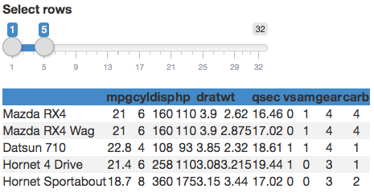

## Confusion Matrix

```r
cm$table %>%
  as.data.frame() %>%
  data.table::dcast(Prediction ~ Reference,
                    value.var = "Freq") %>%
  tableHTML(rownames = FALSE,
            header = c("", "benign", "malignant"),
            second_headers = list(c(2, 2),
                                  c("", "Reference")),
            row_groups = list(2,
                              "Prediction"),
            theme = "scientific",
            class = "conf_matrix") %>%
  add_css_column(columns = c(-1, 1),
                 css = list("font-weight",
                            "bold"))
```

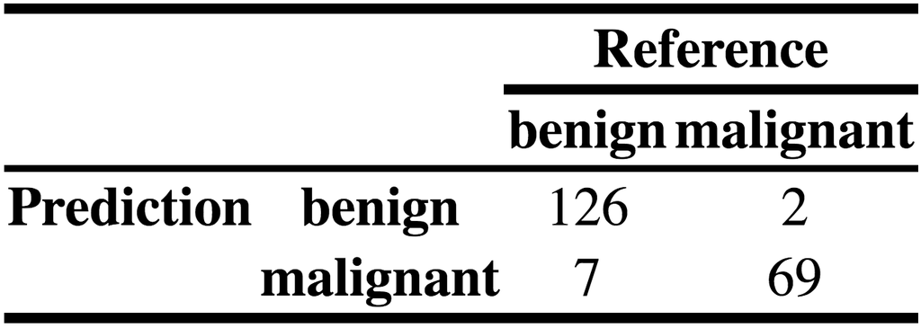

```r
knitr::include_graphics('img/conf_matrix.png')
```

## Future development

- conditional formatting for rows
- Use d3 to create HTML tables?
- Export images from `tableHTML`

## Last Slide

### Questions?

If you need help using the package, there is a `tableHTML` tag on stackoverflow:

https://stackoverflow.com/questions/tagged/tablehtml

If you find any bugs please report them on the issues page on github.

https://github.com/LyzandeR/tableHTML/issues